# Prediction Assignment Writeup

Ramon De LHotellerie

1/27/2021

### Executive Summary

Using devices such as Jawbone Up, Nike FuelBand, and Fitbit it is now possible to collect a large amount of data about personal activity relatively inexpensively. These type of devices are part of the quantified self movement - a group of enthusiasts who take measurements about themselves regularly to improve their health, to find patterns in their behavior, or because they are tech geeks. One thing that people regularly do is quantify how much of a particular activity they do, but they rarely quantify how well they do it. In this project, your goal will be to use data from accelerometers on the belt, forearm, arm, and dumbell of 6 participants.

They were asked to perform barbell lifts correctly and incorrectly in 5 different ways. More information is available from the website here: http://groupware.les.inf.puc-rio.br/har (see the section on the Weight Lifting Exercise Dataset).

### Data source

The data analyzed for this assigment, the Weight Lifting Exercises (WLE) Dataset, come from this source:

[Qualitative Activity Recognition of Weight Lifting Exercises](http://groupware.les.inf.puc-rio.br/har) and refers to Velloso, E.; Bulling, A.; Gellersen, H.; Ugulino, W.; Fuks, H.

The training data for this project is available here:

https://d396qusza40orc.cloudfront.net/predmachlearn/pml-training.csv

The test data is available here:

https://d396qusza40orc.cloudfront.net/predmachlearn/pml-testing.csv

### Summary

The assignment has two main point:

1. **Data analysis**: The dataset will be loaded, described and analyzed.
2. **Prediction of results** - Testing different models that help to predict future results

### Data Analysis

#### Libriaries & Data Loading

```r
## libraries load
library(knitr)
library(caret)
```

```r
library(rpart)
library(rpart.plot)
library(rattle)
library(randomForest)
library(corrplot)
## data load
download.file("https://d396qusza40orc.cloudfront.net/predmachlearn/pml-training.csv", dest="pml-training.csv", mode="wb")
download.file("https://d396qusza40orc.cloudfront.net/predmachlearn/pml-testing.csv", dest="pml-testing.csv", mode="wb")
```

```r
## Gathering Training & Test data
dataTrain <- read.csv("pml-training.csv")
dataTest <- read.csv("pml-testing.csv")
head(dataTrain)
```

```
##   X user_name raw_timestamp_part_1 raw_timestamp_part_2   cvtd_timestamp
## 1 1  carlitos           1323084231               788290 05/12/2011 11:23
## 2 2  carlitos           1323084231               808298 05/12/2011 11:23
## 3 3  carlitos           1323084231               820366 05/12/2011 11:23
## 4 4  carlitos           1323084232               120339 05/12/2011 11:23
## 5 5  carlitos           1323084232               196328 05/12/2011 11:23
## 6 6  carlitos           1323084232               304277 05/12/2011 11:23
##   new_window num_window roll_belt pitch_belt yaw_belt total_accel_belt
## 1         no         11      1.41       8.07    -94.4                3
## 2         no         11      1.41       8.07    -94.4                3
## 3         no         11      1.42       8.07    -94.4                3
## 4         no         12      1.48       8.05    -94.4                3
## 5         no         12      1.48       8.07    -94.4                3
## 6         no         12      1.45       8.06    -94.4                3
##   kurtosis_roll_belt kurtosis_picth_belt kurtosis_yaw_belt skewness_roll_belt
```

[output cut: 251 more lines]

```r
head(dataTest)
```

```
##   X user_name raw_timestamp_part_1 raw_timestamp_part_2   cvtd_timestamp
## 1 1     pedro           1323095002               868349 05/12/2011 14:23
## 2 2    jeremy           1322673067               778725 30/11/2011 17:11
## 3 3    jeremy           1322673075               342967 30/11/2011 17:11
## 4 4    adelmo           1322832789               560311 02/12/2011 13:33
## 5 5    eurico           1322489635               814776 28/11/2011 14:13
## 6 6    jeremy           1322673149               510661 30/11/2011 17:12
##   new_window num_window roll_belt pitch_belt yaw_belt total_accel_belt
## 1         no         74    123.00      27.00    -4.75               20
## 2         no        431      1.02       4.87   -88.90                4
## 3         no        439      0.87       1.82   -88.50                5
## 4         no        194    125.00     -41.60   162.00               17
## 5         no        235      1.35       3.33   -88.60                3
## 6         no        504     -5.92       1.59   -87.70                4
##   kurtosis_roll_belt kurtosis_picth_belt kurtosis_yaw_belt skewness_roll_belt
```

[output cut: 251 more lines]

```r
# Data partition
inTrain <- createDataPartition(y=dataTrain$classe, p=0.7, list=FALSE)
Rtraining <- dataTrain[inTrain, ]
Rtesting <- dataTrain[-inTrain, ]
dim(Rtesting)
```

```
## [1] 5885  160
```

```r
# Removing w/ zero variance variables
NZV_1 <- nearZeroVar(Rtraining, saveMetrics = TRUE)
NZV_1
```

```
##                            freqRatio percentUnique zeroVar   nzv
## X                           1.000000  100.00000000   FALSE FALSE
## user_name                   1.136177    0.04367766   FALSE FALSE
## raw_timestamp_part_1        1.033333    6.09303341   FALSE FALSE
## raw_timestamp_part_2        1.250000   89.39360850   FALSE FALSE
## cvtd_timestamp              1.017408    0.14559220   FALSE FALSE
## new_window                 46.864111    0.01455922   FALSE  TRUE
## num_window                  1.033333    6.23862561   FALSE FALSE
## roll_belt                   1.102236    8.18228143   FALSE FALSE
## pitch_belt                  1.022727   12.12782995   FALSE FALSE
## yaw_belt                    1.116618   13.17609376   FALSE FALSE
## total_accel_belt            1.038929    0.21110868   FALSE FALSE
## kurtosis_roll_belt       1921.428571    2.05284997   FALSE  TRUE
## kurtosis_picth_belt       517.307692    1.68886948   FALSE  TRUE
## kurtosis_yaw_belt          46.864111    0.01455922   FALSE  TRUE
## skewness_roll_belt       2241.666667    2.05284997   FALSE  TRUE
## skewness_roll_belt.1      517.307692    1.78350440   FALSE  TRUE
## skewness_yaw_belt          46.864111    0.01455922   FALSE  TRUE
## max_roll_belt               1.000000    1.16473757   FALSE FALSE
## max_picth_belt              1.479167    0.15287181   FALSE FALSE
## max_yaw_belt              517.307692    0.42949698   FALSE  TRUE
## min_roll_belt               1.142857    1.10650069   FALSE FALSE
## min_pitch_belt              2.000000    0.10191454   FALSE FALSE
## min_yaw_belt              517.307692    0.42949698   FALSE  TRUE
## amplitude_roll_belt         1.363636    0.84443474   FALSE FALSE
## amplitude_pitch_belt        2.980769    0.08735532   FALSE FALSE
## amplitude_yaw_belt         49.630996    0.02911844   FALSE  TRUE
## var_total_accel_belt        1.482759    0.34214166   FALSE FALSE
## avg_roll_belt               1.083333    1.04826381   FALSE FALSE
## stddev_roll_belt            1.081081    0.39309893   FALSE FALSE
## var_roll_belt               1.419355    0.49501347   FALSE FALSE
## avg_pitch_belt              1.500000    1.20113562   FALSE FALSE
## stddev_pitch_belt           1.088889    0.27662517   FALSE FALSE
## var_pitch_belt              1.253731    0.37853971   FALSE FALSE
## avg_yaw_belt                1.500000    1.32488899   FALSE FALSE
## stddev_yaw_belt             1.564103    0.34942127   FALSE FALSE
## var_yaw_belt                1.516129    0.79347747   FALSE FALSE
## gyros_belt_x                1.111957    0.92451045   FALSE FALSE
## gyros_belt_y                1.139013    0.48045425   FALSE FALSE
## gyros_belt_z                1.020635    1.18657640   FALSE FALSE
```

[output cut: 106 more lines]

```
## stddev_pitch_forearm       25.000000    1.72526753   FALSE  TRUE
## var_pitch_forearm          50.000000    1.73254714   FALSE  TRUE
## avg_yaw_forearm            50.000000    1.73254714   FALSE  TRUE
## stddev_yaw_forearm         51.000000    1.72526753   FALSE  TRUE
## var_yaw_forearm            51.000000    1.72526753   FALSE  TRUE
## gyros_forearm_x             1.073239    2.05284997   FALSE FALSE
## gyros_forearm_y             1.087273    5.19764141   FALSE FALSE
## gyros_forearm_z             1.111437    2.11836646   FALSE FALSE
## accel_forearm_x             1.081967    5.66353643   FALSE FALSE
## accel_forearm_y             1.044118    7.11217879   FALSE FALSE
## accel_forearm_z             1.044643    4.03290384   FALSE FALSE
## magnet_forearm_x            1.207547   10.54815462   FALSE FALSE
## magnet_forearm_y            1.183333   13.31440635   FALSE FALSE
## magnet_forearm_z            1.000000   11.66921453   FALSE FALSE
## classe                      1.469526    0.03639805   FALSE FALSE
```

```r
Nzv_1 <- nearZeroVar(Rtraining)
Rtraining <- Rtraining[,-Nzv_1]
dim(Rtraining)
```

```
## [1] 13737   104
```

```r
Rtesting <- Rtesting[,-Nzv_1]
dim(Rtesting)
```

```
## [1] 5885  104
```

```r
# Remove NA variables
RNA <- sapply(Rtraining,function(x) mean(is.na(x))) > 0.95
Rtraining <- Rtraining[,RNA==FALSE]
Rtesting <- Rtesting[,RNA==FALSE]
head(Rtraining)
```

```
##   X user_name raw_timestamp_part_1 raw_timestamp_part_2   cvtd_timestamp
## 2 2  carlitos           1323084231               808298 05/12/2011 11:23
## 3 3  carlitos           1323084231               820366 05/12/2011 11:23
## 4 4  carlitos           1323084232               120339 05/12/2011 11:23
## 6 6  carlitos           1323084232               304277 05/12/2011 11:23
## 7 7  carlitos           1323084232               368296 05/12/2011 11:23
## 8 8  carlitos           1323084232               440390 05/12/2011 11:23
##   num_window roll_belt pitch_belt yaw_belt total_accel_belt gyros_belt_x
## 2         11      1.41       8.07    -94.4                3         0.02
## 3         11      1.42       8.07    -94.4                3         0.00
## 4         12      1.48       8.05    -94.4                3         0.02
## 6         12      1.45       8.06    -94.4                3         0.02
## 7         12      1.42       8.09    -94.4                3         0.02
## 8         12      1.42       8.13    -94.4                3         0.02
##   gyros_belt_y gyros_belt_z accel_belt_x accel_belt_y accel_belt_z
```

[output cut: 69 more lines]

```r
head(Rtesting)
```

```
##     X user_name raw_timestamp_part_1 raw_timestamp_part_2   cvtd_timestamp
## 1   1  carlitos           1323084231               788290 05/12/2011 11:23
## 5   5  carlitos           1323084232               196328 05/12/2011 11:23
## 9   9  carlitos           1323084232               484323 05/12/2011 11:23
## 12 12  carlitos           1323084232               528316 05/12/2011 11:23
## 14 14  carlitos           1323084232               576390 05/12/2011 11:23
## 18 18  carlitos           1323084232               732306 05/12/2011 11:23
##    num_window roll_belt pitch_belt yaw_belt total_accel_belt gyros_belt_x
## 1          11      1.41       8.07    -94.4                3         0.00
## 5          12      1.48       8.07    -94.4                3         0.02
## 9          12      1.43       8.16    -94.4                3         0.02
## 12         12      1.43       8.18    -94.4                3         0.02
## 14         12      1.42       8.21    -94.4                3         0.02
## 18         12      1.55       8.08    -94.4                3         0.00
##    gyros_belt_y gyros_belt_z accel_belt_x accel_belt_y accel_belt_z
```

[output cut: 69 more lines]

```r
dim(Rtesting)
```

```
## [1] 5885   59
```

```r
# removing identification (columns 1 to 5)
Rtraining <- Rtraining[, -(1:5)]
Rtesting  <- Rtesting[, -(1:5)]
dim(Rtraining)
```

```
## [1] 13737    54
```

```r
dim(Rtesting)
```

```
## [1] 5885   54
```

Once we have clean Training and Testing data, we can start predicting, using different prediction models to be compared to each other in their results.

### Prediction of results

#### Generalized Boosted Model

```r
set.seed(12345)
GBModel <- trainControl(method="repeatedcv", number=5, repeats=1)
modFitGBmodel <- train( classe ~., data=Rtraining, method="gbm", trControl= GBModel, verbose=FALSE)
modFitGBmodel$finalModel
```

```
## A gradient boosted model with multinomial loss function.
## 150 iterations were performed.
## There were 53 predictors of which 53 had non-zero influence.
```

#### Random Forest Model

```r
set.seed(12345)
RFModel <- trainControl(method="cv", number=3, verboseIter=FALSE)
modFitRFmodel <- train(classe ~., data=Rtraining, method="rf", trControl=RFModel)
modFitRFmodel$finalModel
```

```
##
## Call:
##  randomForest(x = x, y = y, mtry = param$mtry)
##                Type of random forest: classification
##                      Number of trees: 500
## No. of variables tried at each split: 27
##
##         OOB estimate of  error rate: 0.19%
## Confusion matrix:
##      A    B    C    D    E  class.error
## A 3905    0    0    0    1 0.0002560164
## B    4 2652    1    1    0 0.0022573363
## C    0    4 2392    0    0 0.0016694491
## D    0    0    9 2243    0 0.0039964476
## E    0    0    0    6 2519 0.0023762376
```

Now that both models are in place, I inspect and compare their accuracy results

```r
# predicting with GB Model
predictGBModel <- predict(modFitGBmodel, newdata=Rtesting)
conf.matrix.GBModel <- confusionMatrix(predictGBModel, Rtesting$classe)
conf.matrix.GBModel
```

```
## Confusion Matrix and Statistics
##
##           Reference
## Prediction    A    B    C    D    E
##          A 1672   10    0    1    0
##          B    2 1115    7    6    4
##          C    0   14 1016   13    2
##          D    0    0    3  944   11
##          E    0    0    0    0 1065
##
## Overall Statistics
##
##                Accuracy : 0.9876
##                  95% CI : (0.9844, 0.9903)
##     No Information Rate : 0.2845
##     P-Value [Acc > NIR] : < 2.2e-16
##
##                   Kappa : 0.9843
##
##  Mcnemar's Test P-Value : NA
##
## Statistics by Class:
##
##                      Class: A Class: B Class: C Class: D Class: E
## Sensitivity            0.9988   0.9789   0.9903   0.9793   0.9843
## Specificity            0.9974   0.9960   0.9940   0.9972   1.0000
## Pos Pred Value         0.9935   0.9832   0.9722   0.9854   1.0000
## Neg Pred Value         0.9995   0.9949   0.9979   0.9959   0.9965
## Prevalence             0.2845   0.1935   0.1743   0.1638   0.1839
## Detection Rate         0.2841   0.1895   0.1726   0.1604   0.1810
## Detection Prevalence   0.2860   0.1927   0.1776   0.1628   0.1810
## Balanced Accuracy      0.9981   0.9875   0.9921   0.9882   0.9921
```

```r
prediction.testing.RFModel <- predict(modFitRFmodel, newdata=Rtesting)
conf.matrix.RFModel <- confusionMatrix(prediction.testing.RFModel,Rtesting$classe)
conf.matrix.RFModel
```

```
## Confusion Matrix and Statistics
##
##           Reference
## Prediction    A    B    C    D    E
##          A 1673    1    0    0    0
##          B    1 1137    1    0    2
##          C    0    1 1025    3    0
##          D    0    0    0  960    1
##          E    0    0    0    1 1079
##
## Overall Statistics
##
##                Accuracy : 0.9981
##                  95% CI : (0.9967, 0.9991)
##     No Information Rate : 0.2845
##     P-Value [Acc > NIR] : < 2.2e-16
##
##                   Kappa : 0.9976
##
##  Mcnemar's Test P-Value : NA
##
## Statistics by Class:
##
##                      Class: A Class: B Class: C Class: D Class: E
## Sensitivity            0.9994   0.9982   0.9990   0.9959   0.9972
## Specificity            0.9998   0.9992   0.9992   0.9998   0.9998
## Pos Pred Value         0.9994   0.9965   0.9961   0.9990   0.9991
## Neg Pred Value         0.9998   0.9996   0.9998   0.9992   0.9994
## Prevalence             0.2845   0.1935   0.1743   0.1638   0.1839
## Detection Rate         0.2843   0.1932   0.1742   0.1631   0.1833
## Detection Prevalence   0.2845   0.1939   0.1749   0.1633   0.1835
## Balanced Accuracy      0.9996   0.9987   0.9991   0.9978   0.9985
```

Then, next step is to visualize the GBModel

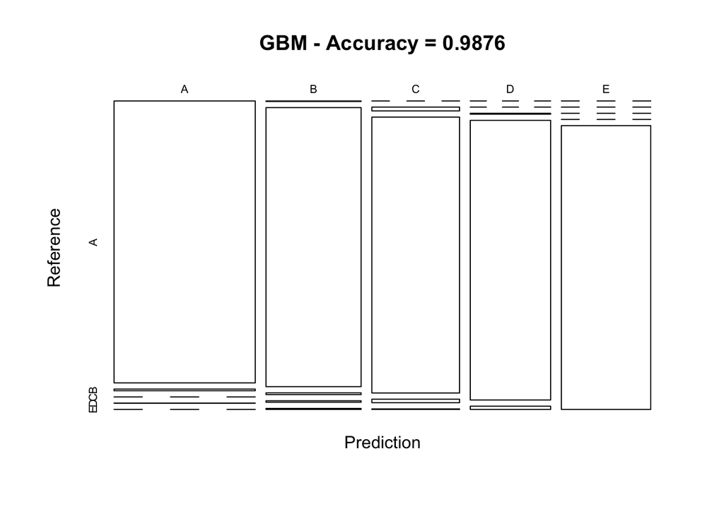

```r
plot(conf.matrix.GBModel$table, col = conf.matrix.GBModel$byClass,
     main = paste("GBM - Accuracy =", round(conf.matrix.GBModel$overall['Accuracy'], 4)))
```

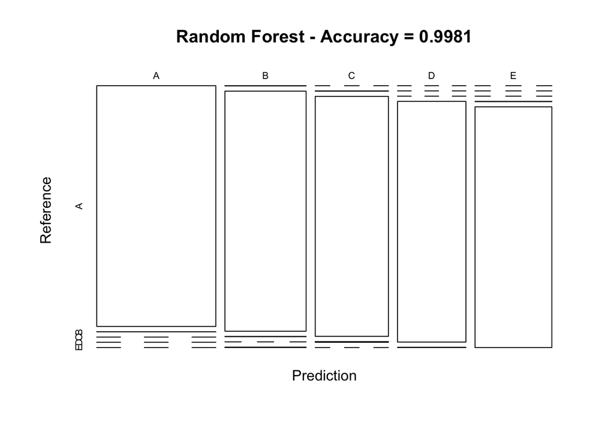

```r
plot(conf.matrix.RFModel$table, col = conf.matrix.RFModel$byClass,
     main = paste("Random Forest - Accuracy =", round(conf.matrix.RFModel$overall['Accuracy'], 4)))
```

Therefore, I decide to predict based on the most accurate model

```r
predicttesting <- predict(modFitRFmodel, newdata=dataTest)
predicttesting
```

```
##  [1] B A B A A E D B A A B C B A E E A B B B
## Levels: A B C D E
```